# Compositional Data Analysis

2023-12-28

# Load necessary libraries.

```r
library(compositions)  # For compositional data analysis
```

# 1. Data Preparation

```r
data <- read.csv("Model.csv")
data<-data[,-1]
Response <- data[, c("SC1", "SC2", "SC3", "SC4", "SC5", "SC6", "SC7", "SC8")]
data <- data[, !(names(data) %in% c("SC1", "SC2", "SC3", "SC4", "SC5", "SC6", "SC7", "SC8"))]

# Treat Response SC1 to SC8 as composition
Y <- acomp(Response)


# Convert categorical variables to factors and introduce contrast
Time <- factor(data$Time)
Year<-factor(data$Year)

Severity <- factor(data$Severity, ordered = TRUE)
Commercial_small_scale <- factor(data$Commercial.small.scale,c("Small", "Commercial"), ordered = TRUE)


contrasts(Severity)<-"contr.treatment"
contrasts(Commercial_small_scale)<-"contr.treatment"
contrasts(Time)<-"contr.treatment"
contrasts(Year)<-"contr.treatment"

data$Year<-Year
data$Severity<-Severity
data$Commercial.small.scale<-Commercial_small_scale
data$Time<-Time
```

# 2. Compositional Response Regression Model

**2.1. With continuous predictor (Regression).**

Regression model with compositional response and real independent variable is defined using the linear Aitchison structure of the simplex:

$$Y_i = a \oplus X_{i} \odot
b \oplus \varepsilon_{i},$$

where $a$ and $b$ are unknown compositional constants, $Y_i$ is a random composition, $X_i$ is a real random variable or design constant, and finally $\varepsilon_i$ is a compositional random variable with null compositional expectation and a constant variance.

**Interpretation:** The intercept $a$ is the expected composition for X = 0.The slope $b$ may be interpreted as the perturbation applied to the composition if $X$ increases one unit.

**2.2. With categorical predictor (Compositional Analysis of Variance).**

Formally, the compositional analysis of variance model uses the same equation as in regression,

$$Y_i = a \oplus
b_g({X_{i}}) \oplus \varepsilon_{i},$$

where $a$ and $b_g$, $g\in \{g_1, \dots, g_m\}$ are unknown compositional constants, $Y_i$ is a random composition, $X_i$ is a real random variable or design constant, and finally $\varepsilon_i$ is a compositional random variable normally distributed with null compositional expectation and a constant variance.

**Interpretation:** Since the ANOVA models have `identifiability` problem and that we must fix the contrasts we want to use for our factors. In general, we will prefer the treatment contrast. In that way, we will be able to interpret the:

1.) Intercept `a` as the expected response for the first level and,

2.) the remaining constants $b_{g_2}, b_{g_3}, \dots$ as the increments on average response from the first to the second level, from the first to the third, etc.

Thus, we have several compositional constants $a, b_{g_2}, b_{g_3}, \dots,$ a different one for each group $g_i, i = 1, \dots, m$.

**2.3. Linear Models with Several Main Effects.**

Multiple covariables can be added into a linear model simply by adding several of the influence terms into the modeling equation:

$$Y_i = a \oplus X1_{i} \odot
b_1 \oplus X2_{i} \odot b_2 \oplus b_3({X3_{i}}) \oplus \dots \oplus
\varepsilon_{i}.$$

# 3. Implementation in R

We fit compostional linear model using some predictors from our dataset with SC1 to SC8 as the compositional response.

```r
# Get all predictor variable names
predictor_vars <- names(data)

# Create the formula string
formula_str <- paste("ilr(Y) ~", paste(predictor_vars, collapse = " + "))

# Convert the string to a formula
formula <- as.formula(formula_str)
```

```r
model <- lm(formula, data = data)
model
```

```
##
## Call:
## lm(formula = formula, data = data)
##
## Coefficients:
##                                   [,1]        [,2]        [,3]
## (Intercept)                        2.149e+03  -3.738e+03  -4.765e+02
## TimeMid                           -4.525e+00   9.161e+00  -2.086e+00
## TimeWinter                        -3.878e+01   5.057e+01  -5.970e+00
## Year2021                           9.441e+00  -2.125e+01  -3.888e-01
## Year2022                          -5.539e+00  -3.529e+00   9.206e+00
## Severity1                          1.880e+00  -8.323e-01  -3.472e+00
## Severity2                          8.008e-02   1.797e+00  -2.958e+00
## Severity3                          6.785e-01   1.017e+00  -2.296e+00
## Severity4                          2.006e+00  -8.957e-01  -1.625e+00
## Severity5                          2.859e+00  -1.559e+00  -2.834e+00
## Severity6                          1.951e+00  -5.222e-01  -1.613e+00
## Severity7                          3.138e+00  -2.126e+00  -2.367e+00
## Severity8                          9.108e-01   1.797e+00  -3.278e+00
## Rel                               -1.020e+00   2.931e+00  -2.364e+00
## Abs                               -3.553e+00   2.477e+00   1.853e+00
## shannon_diversity                 -1.657e+00   3.019e+00  -4.135e-01
## Av_T2M                            -4.978e+02  -5.597e+02   1.312e+03
## Av_T2MDEW                         -3.085e+02  -9.457e+02   1.307e+03
## Av_T2MWET                          8.594e+02   1.419e+03  -2.648e+03
## Av_TS                             -8.557e+00   9.746e+00   1.676e+01
## Av_T2M_RANGE                       4.980e+00  -7.164e+00  -2.443e+00
## Av_QV2M                           -5.623e+01   1.065e+02  -3.991e+00
## Av_RH2M                           -2.174e+01   4.471e+01   2.799e+00
## Av_PRECTOTCORR                    -9.045e-01  -4.206e+00   1.792e+00
## Av_CLRSKY_SFC_PAR_TOT             -8.717e-01   1.759e+00  -1.576e+00
## Av_ALLSKY_SFC_PAR_TOT             -1.832e+00   2.496e+00   1.560e+00
## Av_PS                              4.088e+00  -1.153e+01   1.959e+00
## Av_WS10M                           8.038e-01  -4.198e+00   1.996e-01
## Av_WD10M                          -1.179e-01   9.952e-02   1.635e-01
## Av_ALLSKY_SFC_LW_DWN              -5.361e-01   2.927e-01   7.265e-01
## Sd_T2M                             8.278e+01  -1.394e+02  -3.490e+01
## Sd_T2MDEW                          4.223e+01  -3.415e+01  -9.716e+01
## Sd_T2MWET                         -9.980e+01   1.263e+02   8.594e+01
## Sd_TS                             -2.496e+01   6.280e+01  -9.979e+00
```

[output cut: 214 more lines]

```
## Entr_T2M                                  NA
## Entr_T2MDEW                               NA
## Entr_T2MWET                               NA
## Entr_TS                                   NA
## Entr_T2M_RANGE                            NA
## Entr_QV2M                                 NA
## Entr_RH2M                                 NA
## Entr_PRECTOTCORR                          NA
## Entr_CLRSKY_SFC_PAR_TOT                   NA
## Entr_ALLSKY_SFC_PAR_TOT                   NA
## Entr_PS                                   NA
## Entr_WS10M                                NA
## Entr_WD10M                                NA
## Entr_ALLSKY_SFC_LW_DWN                    NA
## Commercial.small.scaleCommercial   4.405e-02
```

```r
#frm <- as.formula(paste0(names(ilr(Y)), "~", paste0(unlist(names(data)[1:ncol(data[,-c(6:13)])]), collapse = "+")))

#model = lm(ilr(Y) ~ data$Time + data$Year + log(data$Sd_WD10M) + log(data$Sd_WS10M) + data$Skew_ALLSKY_SFC_LW_DWN + data$Abs +data$Rel +data$shannon_diversity + data$Commercial.small.scale
 #           + data$Skew_PS + data$Sd_PS + data$Kur_T2M + data$Kur_TS  +  data$Kur_ALLSKY_SFC_LW_DWN +
 #             data$Kur_CLRSKY_SFC_PAR_TOT + data$Kur_WS10M+data$Kur_PRECTOTCORR+data$Severity)

#model <- lm(frm, data = data)

#model
```

**Remarks and Comments.**

1.) Log transform should be applied to ratio scaled continuous predictors. We need to identify such variables in our data.

2.) We need to find a way of doing variable selection in this setting, alternatively we seek how to manage high dimensional data in this setting.

3.) The output contains the estimated parameters in Isometric Log-Ratio (ilr) coordinates: the intercept $\hat{a}$ , the slopes $\hat{b}$ for each continuous covariable, and the ANOVA effects $\hat{b}(X)$, with one row for each level beyond the first. The first level of the factor is assumed to have an effect of zero due to the implicit usage of the `contr.treatment` contrasts.

# Estimated compositional parameter (Coefficients).

The output contains the estimated parameters $a$ (intercept) and $b$ (slope) in ilr coordinates. They can be displayed as compositions by:

1.) Intercept.

```r
(a = ilrInv(coef(model)[1,],orig=Y))
```

```
##             SC1             SC2             SC3             SC4             SC5
## " 9.997162e-01" "          ERR" "          BDL" "1.240619e-242" "1.095234e-290"
##             SC6             SC7             SC8
## "4.617996e-108" " 2.838256e-04" " 1.955900e-28"
## attr(,"class")
## [1] "acomp"
```

2.) Slope.

```r
(b = ilrInv(rbind(0,coef(model)[-1,]),orig=Y))
```

```
##                                  SC1            SC2             SC3
##                                  "1.250000e-01" " 1.250000e-01" " 1.250000e-01"
## TimeMid                          "3.274028e-04" " 5.439974e-07" " 9.950521e-01"
## TimeWinter                       "1.022751e-15" " 1.549365e-39" " 1.000000e+00"
## Year2021                         "1.589207e-06" " 9.999979e-01" " 6.244354e-15"
## Year2022                         "5.103588e-03" " 2.023014e-06" " 1.347899e-06"
## Severity1                        "4.194690e-02" " 5.986523e-01" " 5.717799e-02"
## Severity2                        "6.034546e-02" " 6.758151e-02" " 5.766318e-01"
## Severity3                        "6.632255e-02" " 1.731287e-01" " 3.723912e-01"
## Severity4                        "3.233230e-02" " 5.513610e-01" " 4.457871e-02"
## Severity5                        "1.382605e-02" " 7.878462e-01" " 1.546940e-02"
## Severity6                        "2.695533e-02" " 4.256459e-01" " 5.650801e-02"
## Severity7                        "1.007708e-02" " 8.519722e-01" " 6.855069e-03"
## Severity8                        "1.989089e-02" " 7.212343e-02" " 3.420380e-01"
## Rel                              "3.540659e-02" " 8.362933e-03" " 6.237110e-01"
## Abs                              "1.906251e-01" " 1.253039e-03" " 3.211118e-01"
## shannon_diversity                "5.385723e-02" " 5.167470e-03" " 6.728152e-01"
## Av_T2M                           "1.891324e-23" "          BDL" "          BDL"
## Av_T2MDEW                        "7.825900e-04" "2.439459e-193" "          BDL"
## Av_T2MWET                        "1.702178e-13" "          ERR" "          ERR"
## Av_TS                            "3.135032e-08" " 1.739402e-13" " 1.127338e-05"
## Av_T2M_RANGE                     "8.698412e-04" " 9.954433e-01" " 4.549527e-06"
## Av_QV2M                          "4.105668e-40" " 1.193011e-74" " 1.000000e+00"
## Av_RH2M                          "7.836032e-18" " 3.470068e-31" " 1.000000e+00"
## Av_PRECTOTCORR                   "2.843046e-01" " 7.911187e-02" " 8.689019e-04"
## Av_CLRSKY_SFC_PAR_TOT            "1.137574e-01" " 3.315830e-02" " 5.296344e-01"
## Av_ALLSKY_SFC_PAR_TOT            "5.839891e-02" " 4.375706e-03" " 3.398952e-01"
## Av_PS                            "3.009252e-03" " 9.751096e-01" " 3.998460e-08"
## Av_WS10M                         "1.989448e-01" " 6.200561e-01" " 2.054911e-03"
## Av_WD10M                         "1.291474e-01" " 1.093188e-01" " 1.342230e-01"
## Av_ALLSKY_SFC_LW_DWN             "1.169938e-01" " 5.481223e-02" " 1.146056e-01"
## Sd_T2M                           "1.441682e-51" " 1.000000e+00" "2.659943e-100"
## Sd_T2MDEW                        "1.159744e-26" " 1.000000e+00" " 7.404483e-32"
## Sd_T2MWET                        "2.854892e-37" " 1.437459e-98" " 9.801849e-01"
## Sd_TS                            "1.811226e-26" " 8.524777e-42" " 1.000000e+00"
## Sd_T2M_RANGE                     "2.386438e-10" " 4.203876e-20" " 2.218586e-08"
## Sd_QV2M                          "1.165989e-25" " 4.617109e-09" " 9.372595e-40"
## Sd_RH2M                          "2.800128e-02" " 4.172159e-04" " 4.216952e-01"
## Sd_PRECTOTCORR                   "2.156633e-02" " 8.700628e-01" " 2.680491e-03"
## Sd_CLRSKY_SFC_PAR_TOT            "3.932411e-02" " 1.651611e-03" " 4.981789e-01"
```

[output cut: 211 more lines]

```
## Entr_T2MWET                      "        MNAR" "        MNAR"
## Entr_TS                          "        MNAR" "        MNAR"
## Entr_T2M_RANGE                   "        MNAR" "        MNAR"
## Entr_QV2M                        "        MNAR" "        MNAR"
## Entr_RH2M                        "        MNAR" "        MNAR"
## Entr_PRECTOTCORR                 "        MNAR" "        MNAR"
## Entr_CLRSKY_SFC_PAR_TOT          "        MNAR" "        MNAR"
## Entr_ALLSKY_SFC_PAR_TOT          "        MNAR" "        MNAR"
## Entr_PS                          "        MNAR" "        MNAR"
## Entr_WS10M                       "        MNAR" "        MNAR"
## Entr_WD10M                       "        MNAR" "        MNAR"
## Entr_ALLSKY_SFC_LW_DWN           "        MNAR" "        MNAR"
## Commercial.small.scaleCommercial "6.103888e-02" "5.285516e-02"
## attr(,"class")
## [1] "acomp"
```

# Visualizing the model

The parameters can graphically be represented as compositions. Below is a bar chart representation of the parameters of the model with compositional response and several main effects. Each bar is associated to a continuous predictor or level of a categorical predictors.

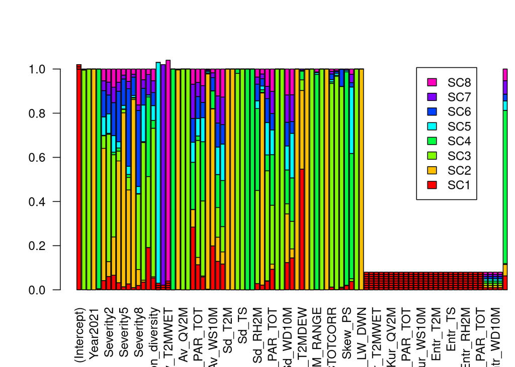

```r
coefs <- ilrInv(coef(model),orig=Y)
# Define a color palette
colors <- rainbow(ncol(coefs))

# Create the bar plot with colors
barplot(coefs, las=2, xlim=c(0, 95), col=colors)
```

# Testing the Influence of Each Variable

The output of the `summary` command for a truly multivariate model in ilr coordinates does not make much sense, as it tests each coordinate separately and not as a whole. However, we can use the `anova.mlm` to check for the joint significance of the influence of $X$; precisely the `anova` command is used to test that the role of each variable is significant:

```r
anova(model)
```

```
## Analysis of Variance Table
##
##                         Df Pillai approx F num Df den Df   Pr(>F)
## (Intercept)              1 1.0000    87073      7      1 0.002609 **
## Time                     2 1.4885        1     14      4 0.647047
## Year                     2 1.9563       13     14      4 0.012250 *
## Severity                 8 4.0974        1     56     49 0.226268
## Rel                      1 1.0000    67967      7      1 0.002953 **
## Abs                      1 1.0000     6494      7      1 0.009555 **
## shannon_diversity        1 1.0000    73890      7      1 0.002833 **
## Av_T2M                   1 1.0000    10435      7      1 0.007538 **
## Av_T2MDEW                1 1.0000     4357      7      1 0.011664 *
## Av_T2MWET                1 1.0000    12824      7      1 0.006799 **
## Av_TS                    1 0.9884       12      7      1 0.217530
## Av_T2M_RANGE             1 1.0000     7578      7      1 0.008845 **
## Av_QV2M                  1 1.0000    30516      7      1 0.004408 **
## Av_RH2M                  1 1.0000    13601      7      1 0.006602 **
## Av_PRECTOTCORR           1 1.0000    23622      7      1 0.005010 **
## Av_CLRSKY_SFC_PAR_TOT    1 0.9994      243      7      1 0.049392 *
## Av_ALLSKY_SFC_PAR_TOT    1 1.0000     6491      7      1 0.009557 **
## Av_PS                    1 0.9999     2578      7      1 0.015165 *
## Av_WS10M                 1 1.0000    23658      7      1 0.005006 **
## Av_WD10M                 1 1.0000   120957      7      1 0.002214 **
## Av_ALLSKY_SFC_LW_DWN     1 0.9999     1384      7      1 0.020693 *
## Sd_T2M                   1 1.0000    28538      7      1 0.004558 **
## Sd_T2MDEW                1 1.0000     8914      7      1 0.008155 **
## Sd_T2MWET                1 0.9999     2192      7      1 0.016444 *
## Sd_TS                    1 0.9993      206      7      1 0.053605 .
## Sd_T2M_RANGE             1 1.0000    70178      7      1 0.002907 **
## Sd_QV2M                  1 0.9999     2853      7      1 0.014415 *
## Sd_RH2M                  1 1.0000    12143      7      1 0.006987 **
## Sd_PRECTOTCORR           1 1.0000    22967      7      1 0.005081 **
## Sd_CLRSKY_SFC_PAR_TOT    1 1.0000   150737      7      1 0.001983 **
## Sd_ALLSKY_SFC_PAR_TOT    1 0.9998      578      7      1 0.032029 *
## Sd_PS                    1 0.9997      513      7      1 0.033994 *
## Sd_WS10M                 1 0.9491        3      7      1 0.440560
## Sd_WD10M                 1 0.9970       47      7      1 0.111366
## Sd_ALLSKY_SFC_LW_DWN     1 0.9969       46      7      1 0.113659
## Skew_T2M                 1 1.0000    11454      7      1 0.007195 **
## Skew_T2MDEW              1 0.9990      141      7      1 0.064744 .
## Skew_T2MWET              1 1.0000    12604      7      1 0.006858 **
## Skew_TS                  1 1.0000    50369      7      1 0.003431 **
## Skew_T2M_RANGE           1 1.0000    40892      7      1 0.003808 **
## Skew_QV2M                1 1.0000    25040      7      1 0.004866 **
## Skew_RH2M                1 0.9993      209      7      1 0.053158 .
## Skew_PRECTOTCORR         1 1.0000     5466      7      1 0.010415 *
## Skew_CLRSKY_SFC_PAR_TOT  1 1.0000    83539      7      1 0.002664 **
## Skew_ALLSKY_SFC_PAR_TOT  1 1.0000    69073      7      1 0.002930 **
## Skew_PS                  1 1.0000    20606      7      1 0.005364 **
## Skew_WS10M               1 0.9972       50      7      1 0.108040
## Skew_WD10M               1 1.0000    14505      7      1 0.006393 **
## Skew_ALLSKY_SFC_LW_DWN   1 0.9988      117      7      1 0.071126 .
## Commercial.small.scale   1 1.0000     6847      7      1 0.009305 **
## Residuals                7
## ---
## Signif. codes:  0 '***' 0.001 '**' 0.01 '*' 0.05 '.' 0.1 ' ' 1
```

**Interpretation:**

Each line of the table corresponds to a test of the form:

$H_0$, null hypothesis: given the preceding $(i-1)$ variables, the $ith$ predictor has no influence. If this is a continuous covariable, we can say that the slope coefficient $b_i=\mathbb{1}$. If this is a factor, we can say that the composition has the same expectation for all levels.

$H_1$, alternative hypothesis: the independent variable of the line is needed, additionally to all preceding variables, i.e., its coefficients $b_i\neq\mathbb{1}$.

**Comment:**

A variable is only needed in the model if it is necessary given that the information from all the other covariables is already used. It is thus necessary to check each covariable as last term in the model. Currently, there is no way to automatize this, since the built-in R command `drop1` is not functional for the “`mlm`” model. We need to manually enumerate each covariable in the last position and extract the test of the last row of the ANOVA table.

We need to do lasso one way or the other or apply some variable selection techniques in this setting.